# L09 Coordinates

Data Visualization (STAT 302)

Noah Holubow

```r
library(knitr)
opts_chunk$set(warning = FALSE, message = FALSE, comment = FALSE, dpi = 300)
```

## Datasets

We’ll be using the `mod_nba2014_15_advanced.txt` dataset — add to your project’s `/data` subdirectory. The `codebook_mod_nba2014_15_advanced.txt` provides a quick description of the variables in the dataset — suggest adding it to the `/data` subdirectory as well.

```r
# Load package(s)
library(tidyverse)

# Read in dataset
nba_dat <- read_delim("data/mod_nba2014_15_advanced.txt", delim = "|") %>%
  janitor::clean_names()
```

## The Exercise

Using the `mod_nba2014_15.txt` dataset we will begin the process of trying to recreate/approximate the plot type featured in the http://fivethirtyeight.com/ article [Kawhi Leonard Is The Most Well-Rounded Elite Shooter Since Larry Bird](http://fivethirtyeight.com/features/kawhi-leonard-is-the-most-well-rounded-elite-shooter-since-larry-bird/) for any player of your choice for the 2014-2015 season.

### Start with data wrangling

When data wrangling we will need a helper function for creating the quartiles for players. Additionally, it will be useful to exclude players that played less than 10 games or played less than 5 minutes a game. That is, we only want to include “qualified” players.

```r
# Returns quartile rank
quartile_rank <- function(x = 0:99) {
  # Set quartile
  quart_breaks <- c(
    -Inf,
    quantile(x,
      probs = c(.25, .5, .75),
      na.rm = TRUE
    ),
    Inf
  )
  cut(x = x, breaks = quart_breaks, labels = FALSE)
}
```

**Add comments to** the code below where indicated. The added comments should concisely describe what the following line(s) of code do in the data wrangling process

```r
# Graphical data
nba_graph_dat <- nba_dat %>%
  # filtering out anyone with less than 10 games or who played less than 5 minutes per game
  filter(g >= 10, mp / g >= 5) %>%
  # creating quartile ranks for each player
  mutate(
    ts_quant = quartile_rank(ts_perc),
    trb_quant = quartile_rank(trb_perc),
    dbpm_quant = quartile_rank(dbpm),
    ast_quant = quartile_rank(ast_perc),
    usg_quant = quartile_rank(usg_perc)
  ) %>%
  # choosing only columns with quant and the player colimn
  select(player, contains("_quant")) %>%
  # using pivot longer to create separate rows for each quant
  pivot_longer(
    cols = -player,
    names_to = "variable",
    values_to = "value"
    ) %>%
  # arranging by player name to group together
  arrange(player) %>%
  filter(player == "LeBron James")
```

#### Start building the plot

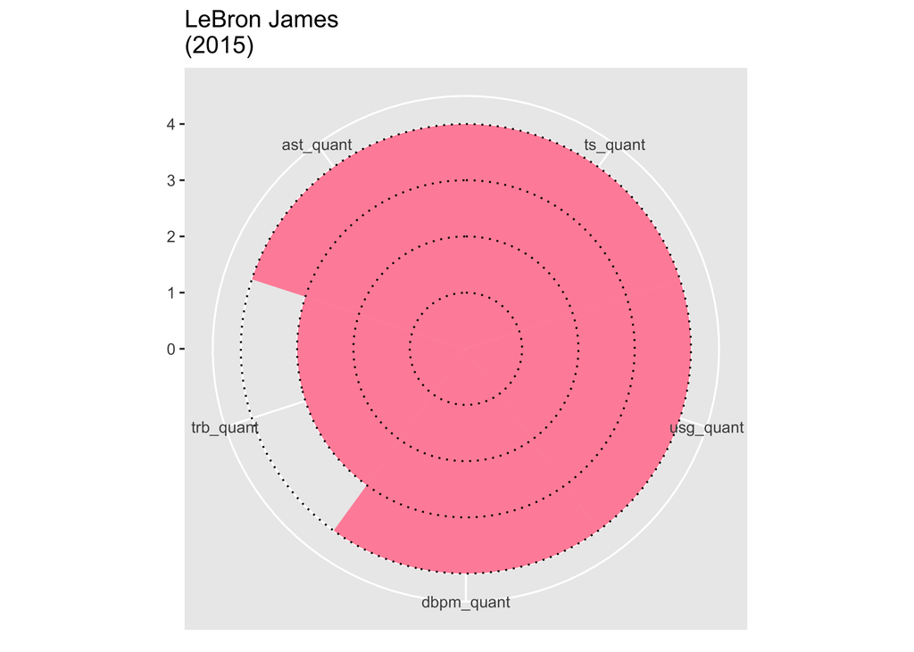

```r
# plot
nba_graph_dat %>%
  ggplot(aes(variable, value)) +
  geom_bar(
    stat = "identity",
    width = 1,
    fill = "#FF91A7") +
  geom_hline(
    yintercept = 1:4,
    linetype = "dotted") +
  scale_x_discrete(
    name = NULL,
    limits = c("ts_quant", "usg_quant", "dbpm_quant", "trb_quant", "ast_quant")
  ) +
  labs(
    title = str_c(nba_graph_dat$player, "\n(2015)"),
    y = NULL
  ) +
  coord_polar()
```